# Homework 10

Matej Popovski

## Problem 1) More regression with `mtcars` (6 points, 1pt each)

In lecture, we worked briefly with the `mtcars` data set. Let’s get more regression practice by working with it some more.

### a) background

Run `?mtcars` in the console (please **do not** add it to this `Rmd` file) and briefly read the help page. Specifically, take note of the following:

1. What is the source of this data? > The dataset was extracted from the 1974 issue of Motor Trend US Magazine. It documents the results of road tests for various automobiles from the 1973–1974 model years.
2. What is this data set measuring (i.e., what was the response variable in the original study, at least based on the brief description in the R documentation)? > The primary response variable is miles per gallon (mpg), which represents fuel consumption efficiency.
3. What predictors are available and what do they mean? > The dataset contains 10 predictors that describe various aspects of automobile design and performance: cyl (number of cylinders, typically 4, 6, or 8), disp (engine displacement in cubic inches), hp (gross horsepower), drat (rear axle ratio), wt (weight of the car in 1000 lbs), qsec (time to cover a 1/4 mile in seconds), vs (engine type, 0 = V-shaped, 1 = straight), am (transmission type, 0 = automatic, 1 = manual), gear (number of forward gears, usually 3, 4, or 5), and carb (number of carburetors, typically ranging from 1 to 8).

You may want to also run `head(mtcars, 10)` or `View(mtcars)` to inspect the data frame briefly before moving on.

```r
head(mtcars, 10)
```

```
##                    mpg cyl  disp  hp drat    wt  qsec vs am gear carb
## Mazda RX4         21.0   6 160.0 110 3.90 2.620 16.46  0  1    4    4
## Mazda RX4 Wag     21.0   6 160.0 110 3.90 2.875 17.02  0  1    4    4
## Datsun 710        22.8   4 108.0  93 3.85 2.320 18.61  1  1    4    1
## Hornet 4 Drive    21.4   6 258.0 110 3.08 3.215 19.44  1  0    3    1
## Hornet Sportabout 18.7   8 360.0 175 3.15 3.440 17.02  0  0    3    2
## Valiant           18.1   6 225.0 105 2.76 3.460 20.22  1  0    3    1
## Duster 360        14.3   8 360.0 245 3.21 3.570 15.84  0  0    3    4
## Merc 240D         24.4   4 146.7  62 3.69 3.190 20.00  1  0    4    2
## Merc 230          22.8   4 140.8  95 3.92 3.150 22.90  1  0    4    2
## Merc 280          19.2   6 167.6 123 3.92 3.440 18.30  1  0    4    4
```

### b) Fitting a model

Use `lm` to run a regression of `mpg` on a few predictors in the data frame (choose two or three that you think would make a good model – don’t use all ten; we’ll talk about why in later lectures). Save your fitted model as an object called `lm.mtcars`. Make sure to include `data = mtcars` as a keyword argument to `lm` so that R knows what data frame to use.

Briefly inspect the residuals plot by running `plot(lm.mtcars,ask=F,which=1:2)`. What do you observe, and what does it mean?

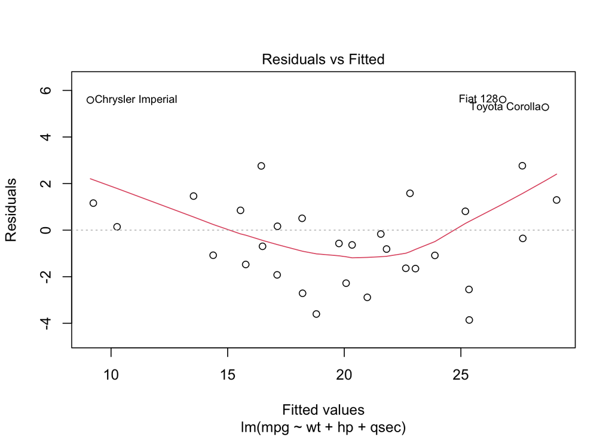

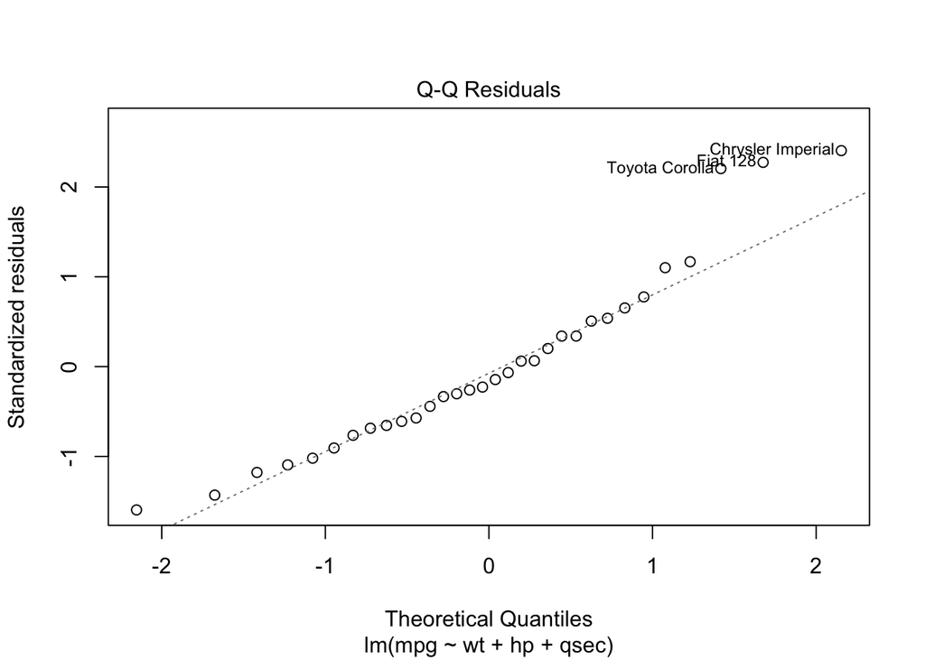

```r
# Fit a regression model with mpg as the response variable
lm.mtcars <- lm(mpg ~ wt + hp + qsec, data = mtcars)

# Inspect residual plots
plot(lm.mtcars, ask = FALSE, which = 1:2)
```

> The Residuals vs Fitted plot indicates that the residuals are not entirely randomly scattered. Notably, there is an accumulation of positive residuals at the tails, while in the fitted value range of 17 to 22, there are predominantly negative residuals. This pattern suggests potential issues with the linearity assumption or model specification.

> The standardized residuals generally follow the theoretical quantile line, indicating that the residuals are approximately normally distributed. However, deviations are observed at the tails, with a few outliers particularly noticeable in the right tail, suggesting potential departures from normality in these extreme values.

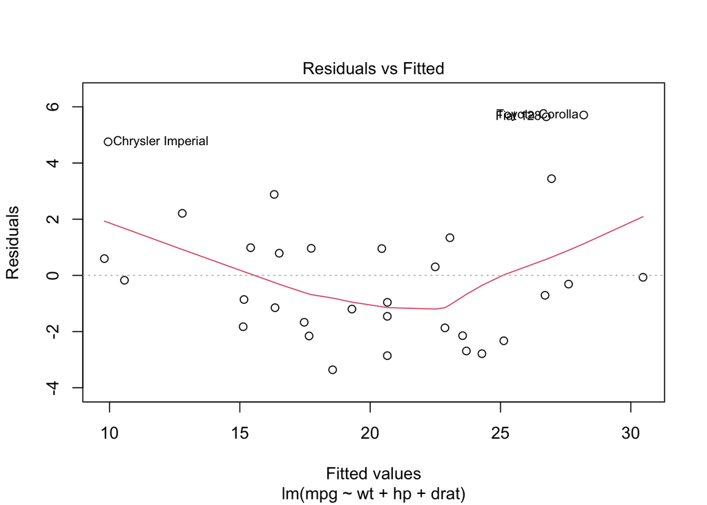

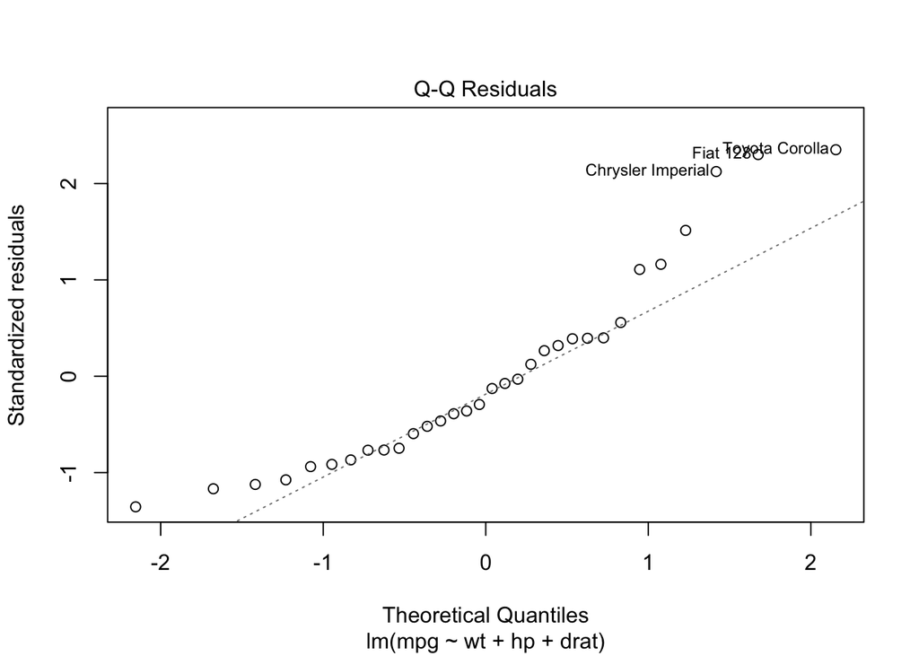

```r
lm.mtcars <- lm(mpg ~ wt + hp + drat, data = mtcars)

plot(lm.mtcars,ask=F,which=1:2)
```

> In this example of Q-Q plot, the standardized residuals show even poorer fit to the theoretical quantile line, in the left and right tail.

### c) Interpreting the model

View the summary of your model by uncommenting and running the code below.

```r
lm.mtcars <- lm(mpg ~ wt + hp + qsec, data = mtcars)
summary(lm.mtcars)
```

```
##
## Call:
## lm(formula = mpg ~ wt + hp + qsec, data = mtcars)
##
## Residuals:
##     Min      1Q  Median      3Q     Max
## -3.8591 -1.6418 -0.4636  1.1940  5.6092
##
## Coefficients:
##             Estimate Std. Error t value Pr(>|t|)
## (Intercept) 27.61053    8.41993   3.279  0.00278 **
## wt          -4.35880    0.75270  -5.791 3.22e-06 ***
## hp          -0.01782    0.01498  -1.190  0.24418
## qsec         0.51083    0.43922   1.163  0.25463
## ---
## Signif. codes:  0 '***' 0.001 '**' 0.01 '*' 0.05 '.' 0.1 ' ' 1
##
## Residual standard error: 2.578 on 28 degrees of freedom
## Multiple R-squared:  0.8348, Adjusted R-squared:  0.8171
## F-statistic: 47.15 on 3 and 28 DF,  p-value: 4.506e-11
```

Pick one of your predictors and give an interpretation of the estimate and standard error for its coefficient. Be careful in your wording of the interpretation.

Which coefficients are statistically significantly different from zero? How do you know?

> The coefficient for wt (weight) in the regression model has an estimate of -4.35880. This indicates that for every additional 1000 lbs of car weight, the expected miles per gallon (mpg) decreases by approximately 4.36 units, assuming the other predictors (hp and qsec) remain constant. The associated standard error for this coefficient is 0.75270, which measures the variability in the estimate. A smaller standard error, suggests greater precision in the estimate and increases confidence in the effect of weight on mpg.

> In this model, the p-value for wt is 3.22e-06, which is well below 0.05, making it statistically significant. On the other hand, the p-values for hp (0.24418) and qsec (0.25463) are both above 0.05, indicating that these predictors are not statistically significantly different from zero and may not have a meaningful impact on mpg in this model.

> In summary, among the three predictors, only wt shows a statistically significant relationship with mpg, providing strong evidence that car weight is an important factor in determining fuel efficiency. The lack of significance for hp and qsec suggests these predictors may not contribute as effectively to explaining variations in mpg.

### d) Interpreting residuals

What is the Residual Standard Error (RSE) for this model? How many degrees of freedom does it have?

> The Residual Standard Error (RSE) for this model is 2.578. RSE measures the average deviation of the observed mpg values from the predicted values by the model. A smaller RSE indicates that the model’s predictions are closer to the actual data points. In this case, the RSE suggests that the model’s predictions typically deviate from the true mpg values by approximately 2.578 miles per gallon.

> The model has 28 degrees of freedom, which corresponds to the number of observations (32) minus the number of fitted parameters (3 predictors plus the intercept, making 4 parameters). Degrees of freedom reflect the amount of information available for estimating variability.

What is the value of $R^2$ for this model? (**Hint:** look at the output of `summary`) Give an interpretation of this value.

The multiple R-squared value close to 1 suggest a good fit. Value of 0.8348 indicates that approximately 83.48% of the variability in the response variable mpg is explained by the predictors wt, hp and qsec. This means the model fits the data quite well. It always increases when more predictors are added to the model, regardless of whether those predictors are relevant. So it can be optimistic especially with many predictors.

### e) Adjusted $R^2$

Briefly read about the adjusted $R^2$ [here](https://www.statisticshowto.com/probability-and-statistics/statistics-definitions/adjusted-r2/). What is the adjusted $R^2$ of this model and how does this differ from the usual $R^2$ value? (**Hint:** again, look at the output of `summary`).

> R-squared has a tendency to increase as more predictors are added to the model, even if those predictors are not truly meaningful.

> The adjusted R^2 value is a modified version of the regular R^2 value that accounts for the number of predictors in a model. It includes a penalty for adding additional predictors to the model. It increases only if the new predictor improves the model more than would be expected by chance and decreases when the predictor does not add value, giving more realistic estimate of goodness-of-fit.

> adjusted R^2 = 1 - ((1-R^2)(n-1)/(n-k-1))

> n is number of observations and k is number of predictors.

> In our case adjusted R-squared = 0.8171 suggests that predictors hp and qsec do not contribute to explanation of variance. Thus, the adjusted R-squared (0.8171) is slightly lower than the regular R-squared (0.8348), suggesting that after adjusting for the number of predictors, the model explains about 81.71% of the variance in mpg. This makes the adjusted R-squared a more reliable measure of the model’s goodness of fit, especially when comparing models with different numbers of predictors.

### f) CIs for coefficients

Read the documentation for the `confint` function, and use it to generate $95\%$ confidence intervals for the coefficients of your model. Give an interpretation of these confidence intervals.

```r
lm.mtcars <- lm(mpg ~ wt + hp + qsec, data = mtcars)
confint(lm.mtcars, level = 0.95)
```

```
##                  2.5 %      97.5 %
## (Intercept) 10.3630852 44.85796848
## wt          -5.9006341 -2.81696034
## hp          -0.0485098  0.01286526
## qsec        -0.3888708  1.41053822
```

The confidence intervals provide valuable information about the precision and significance of the model coefficients. Narrower intervals indicate more precise estimates, while intervals that do not include zero indicate statistically significant predictors. CI for predictor wt do not include zero and are negative. This means that wt is (also seen by p-value) significantly associated with mpg, and the relationship is negative. As weight increases, mpg decreases. Hp and qsec include zero, and do not significantly contribute to mpg.

## Problem 2) the `cats` data set (8 points; 2pt each)

The `cats` data set, included in the `MASS` library, contains data recorded from 144 cats. Each row of the data set contains the body weight (`Bwt`, in kgs), heart weight (`Hwt`, in grams) and the sex (`Sex`, levels `'F'` and `'M'`) for one of the cats in the data set.

```r
library(MASS)
head(cats)
```

```
##   Sex Bwt Hwt
## 1   F 2.0 7.0
## 2   F 2.0 7.4
## 3   F 2.0 9.5
## 4   F 2.1 7.2
## 5   F 2.1 7.3
## 6   F 2.1 7.6
```

### a) plotting the data

Create a scatter plot showing heart weight on the y-axis and body weight on the x-axis. Ignore the `Sex` variable in this plot.

Briefly describe what you see. Is there a clear trend in the data?

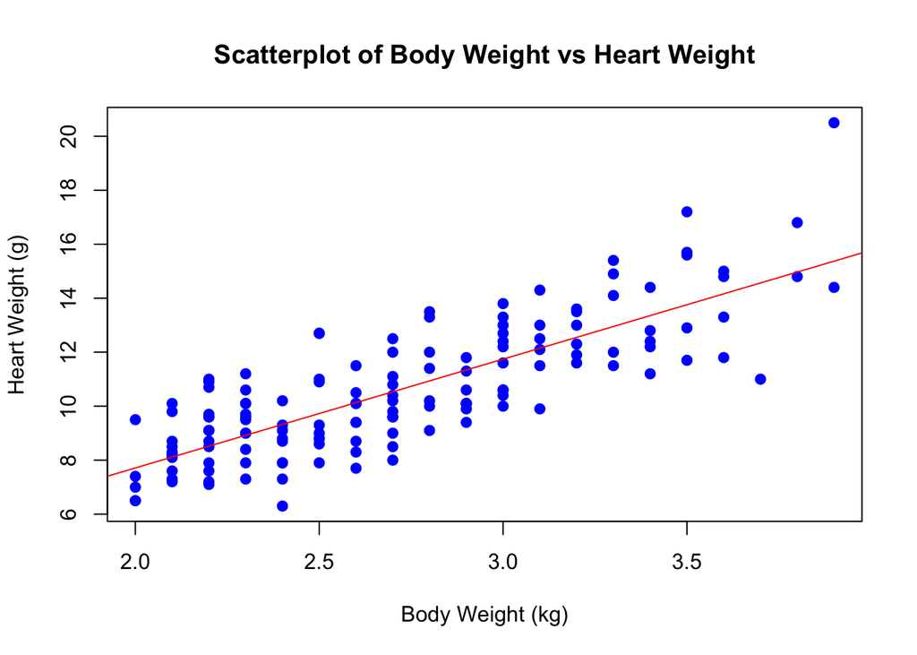

```r
# Load the MASS library
library(MASS)

# Extract the cats dataset
data(cats)

# Create a scatterplot of Bwt vs Hwt
plot(cats$Bwt, cats$Hwt,
     xlab = "Body Weight (kg)",
     ylab = "Heart Weight (g)",
     main = "Scatterplot of Body Weight vs Heart Weight",
     pch = 19, col = "blue")

# Add a trend line
abline(lm(Hwt ~ Bwt, data = cats), col = "red")
```

> A trend showing the linear relationship between the two attributes.

### b) fitting a linear model

Fit a linear regression model to predict cat heart weight from cat body weight (and using an intercept term, of course).

Examine the coefficients of your fitted model. What is the coefficient for the `Bwt` variable? Interpret this coefficient– a unit change in body weight yields how much change in heart weight?

```r
# Fit a linear model predicting Hwt from Bwt
lm.cats <- lm(Hwt ~ Bwt, data = cats)

# View the summary of the fitted model
summary(lm.cats)
```

```
##
## Call:
## lm(formula = Hwt ~ Bwt, data = cats)
##
## Residuals:
##     Min      1Q  Median      3Q     Max
## -3.5694 -0.9634 -0.0921  1.0426  5.1238
##
## Coefficients:
##             Estimate Std. Error t value Pr(>|t|)
## (Intercept)  -0.3567     0.6923  -0.515    0.607
## Bwt           4.0341     0.2503  16.119   <2e-16 ***
## ---
## Signif. codes:  0 '***' 0.001 '**' 0.01 '*' 0.05 '.' 0.1 ' ' 1
##
## Residual standard error: 1.452 on 142 degrees of freedom
## Multiple R-squared:  0.6466, Adjusted R-squared:  0.6441
## F-statistic: 259.8 on 1 and 142 DF,  p-value: < 2.2e-16
```

> Estimated Bwt coefficient is 4.0341. For each unit increase in body weight (Bwt), the heart weight (Hwt) increases by approximately 4.034 grams, on average.

### c) back to plotting

Create the same plot from Part a above, but this time color the points in the scatter plot according to the `Sex` variable. You may use either `ggplot2` or the built-in R plotting tools, though I would recommend the former, for this.

You should see a clear pattern. Describe it. A sentence or two is fine here.

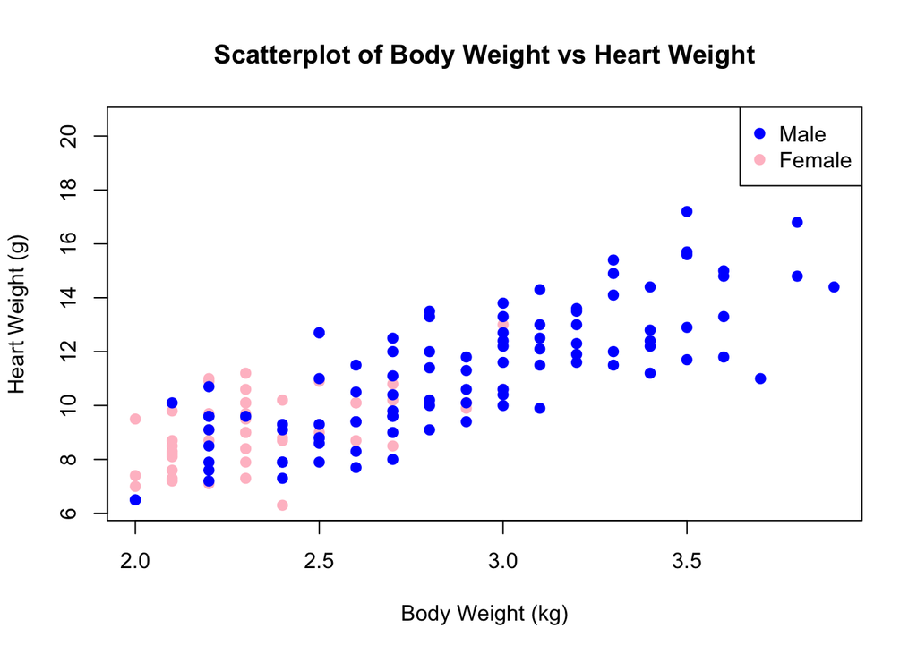

```r
# Load the MASS library
library(MASS)

# Extract the cats dataset
data(cats)

# Create a scatterplot of Bwt vs Hwt with points colored by Sex
plot(cats$Bwt, cats$Hwt,
     xlab = "Body Weight (kg)",
     ylab = "Heart Weight (g)",
     main = "Scatterplot of Body Weight vs Heart Weight",
     pch = 19, col = ifelse(cats$Sex == "M", "blue", "pink"))

# Add a legend
legend("topright", legend = c("Male", "Female"), col = c("blue", "pink"), pch = 19)
```

Female cats are with lower Body weight range than male cats and they have smaller estimate (slope). This means that for each unit increase in body weight for femalse cats, there will be lower increase of the heart weight (Hwt) comparing with male cats.

### d) adding `Sex` and an interaction

From looking at the data, it should be clear that the `Sex` variable has explanatory power in predicting heart weight, but it is also very correlated with body weight.

Fit a new linear regression model, still predicting heart weight, but this time including both body weight and sex as predictors *and* an interaction term between body weight and sex. Take note of how R assigns `Sex` a dummy encoding.

Examine the outputs of your model. In particular, note the coefficients of `Sex` and the interaction between `Bwt` and `Sex`. Are both of these coefficients statistically significantly different from zero? How do you interpret the interaction term?

```r
# Fit the linear regression model with an interaction term between Bwt and Sex
lm.cats <- lm(Hwt ~ Bwt * Sex, data = cats)

# View the summary of the model to inspect coefficients
summary(lm.cats)
```

```
##
## Call:
## lm(formula = Hwt ~ Bwt * Sex, data = cats)
##
## Residuals:
##     Min      1Q  Median      3Q     Max
## -3.7728 -1.0118 -0.1196  0.9272  4.8646
##
## Coefficients:
##             Estimate Std. Error t value Pr(>|t|)
## (Intercept)   2.9813     1.8428   1.618 0.107960
## Bwt           2.6364     0.7759   3.398 0.000885 ***
## SexM         -4.1654     2.0618  -2.020 0.045258 *
## Bwt:SexM      1.6763     0.8373   2.002 0.047225 *
## ---
## Signif. codes:  0 '***' 0.001 '**' 0.01 '*' 0.05 '.' 0.1 ' ' 1
##
## Residual standard error: 1.442 on 140 degrees of freedom
## Multiple R-squared:  0.6566, Adjusted R-squared:  0.6493
## F-statistic: 89.24 on 3 and 140 DF,  p-value: < 2.2e-16
```

> R assigns Sex a dummy encoding by treating the female category as the reference group (with a coefficient of zero) and encoding the male category as SexM, which reflects the difference in heart weight for male cats compared to female cats.

> All tree coefficient for Body Weight (Bwt), SexM (male cats) and the interaction term between Bwt and Sex (Bwt:SexM) are statistically significant at the 5% level, with p-values of 0.000885, 0.045 and 0.047, respectively.

> For female cats, each unit increase in body weight is associated with an increase of 2.6364 units in heart weight. The coefficient for SexM indicates that male cats have a heart weight that is, on average, 4.1654 grams less than female cats, after adjusting for body weight. The interaction term (Bwt:SexM) suggests that the relationship between body weight (Bwt) and heart weight is different for male and female cats. Specifically, for male cats, the effect of body weight on heart weight is 1.6763 grams more per kilogram of body weight than for female cats. This implies that while both male and female cats show a positive relationship between body weight and heart weight, the effect is stronger in male cats. R^2 and Adjusted R^2 indicate that the model explains approximately 65.66% and 64.93% respectively of the variance in heart weight, and the model as a whole is highly significant (p < 2.2e-16).

## Problem 3) Quantitative and Categorical Predictors (8 points)

(This problem is based on a plot from [The behavior of different clays subjected to a fast-drying cycle for traditional ceramic manufacturing](https://doi.org/10.1016/j.jksues.2022.05.003), but the data has been simulated)

An experiment was conducted on three types of **material**: Plastic clay, Sandy clay and claystone. The **plastic deformation** (%) was measured at various **moisture** (%) levels. Data is found in the `clay_sample.csv` file. Plastic deformation is denoted `pd` in the dataset.

### a) Fit the model (4 points)

Create a linear model model predicting plastic deformation from moisture. Include material and the interaction between material and moisture.

```r
# Load necessary library
library(readr)

# Read the CSV file
clay_sample <- read_csv("clay_sample.csv", show_col_types = FALSE)
head(clay_sample)
```

```
## # A tibble: 6 × 3
##   material     moisture    pd
##   <chr>           <dbl> <dbl>
## 1 sandy clay       24.5  27.3
## 2 plastic clay     20.6  11.3
## 3 plastic clay     26.8  32.9
## 4 sandy clay       25.7  43.0
## 5 claystone        14.6  10.4
## 6 plastic clay     24.2  17.6
```

a.i. Output the standard model summary using `summary()`.

```r
lm.clay <- lm(pd ~   moisture * material, data = clay_sample)

summary(lm.clay)
```

```
##
## Call:
## lm(formula = pd ~ moisture * material, data = clay_sample)
##
## Residuals:
##     Min      1Q  Median      3Q     Max
## -8.2343 -2.9072 -0.4121  2.6426  7.8457
##
## Coefficients:
##                                Estimate Std. Error t value Pr(>|t|)
## (Intercept)                   -103.1666    11.6696  -8.841 1.07e-12 ***
## moisture                         7.7928     0.7454  10.455 1.77e-15 ***
## materialplastic clay            23.9557    13.2986   1.801 0.076355 .
## materialsandy clay              29.2029    17.7493   1.645 0.104810
## moisture:materialplastic clay   -3.5950     0.7907  -4.547 2.48e-05 ***
## moisture:materialsandy clay     -3.5036     0.9388  -3.732 0.000406 ***
## ---
## Signif. codes:  0 '***' 0.001 '**' 0.01 '*' 0.05 '.' 0.1 ' ' 1
##
## Residual standard error: 4.122 on 64 degrees of freedom
## Multiple R-squared:  0.8776, Adjusted R-squared:  0.868
## F-statistic: 91.77 on 5 and 64 DF,  p-value: < 2.2e-16
```

a.ii. Interpret the $R^2$$ statistic value in one sentence.

> The R-squared statistic represents the proportion of the variance in plastic deformation (pd) that is explained by the model, including moisture levels and material type, and their interaction, with a higher R-squared (87.76%) indicating a better fit of the model to the data.

a.iii. Which material represents the baseline?

> Considering summary results material “claystone” is baseline. The coefficients for “sandy clay” and “plastic clay” are compared to the baseline (“claystone”). These coefficients indicate the difference in plastic deformation (pd) when the material is “sandy clay” or “plastic clay” compared to “claystone”.

a.iv. Explain how the residual standard error degrees of freedom is related to sample size and the model size.

> degrees of freedom = 64 calculated by n - (p+1) = 70 - (5+1) n = 70 rows, 5 parameters + 1 intercept

```r
dim(clay_sample)
```

```
## [1] 70  3
```

### b) Interpret coefficient 1 (1 pt)

Provide an interpretation for the value of the coefficient of moisture, and comment on its significance.

> Moisture estimate = 7.7928 and it is highly significant. P-value = 1.77e-15 < 0.05

### c) Interpret coefficient 2 (1 pt)

Provide an interpretation for the value of the coefficient of one of the materials, and comment on its significance.

> Material plastic clay estimate is 23.9557 Std. Eror is 13.2986 and p-value 0.076355. Plastic Clay has a 23.9557 unit bigger plastic deformation compared to the baseline material (Claystone), holding all other variables fixed. The p-value for Material plastic clay estimate 0.076355 is greater than 0.05, indicating that the difference in plastic deformation between Plastic Clay and Claystone is not statistically significant.

### d) Interpret coefficient 3 (1 pt)

Provide an interpretation for the value of the coefficient of one of the interaction terms, and comment on its significance.

> The coefficient for the interaction term “moisture clay” is -3.5950, which means that for “plastic clay,” the effect of moisture on plastic deformation is 3.595% less than the effect of moisture on the baseline material (claystone). Specifically, as moisture increases, the plastic deformation for “plastic clay” increases at a slower rate compared to claystone. This interaction term is statistically significant with a p-value of 2.48e-05, indicating that the difference in moisture’s effect between “plastic clay” and “claystone” is highly significant.

### e) Assess assumptions (1 pt)

Finally display the first two diagnostic plots using `plot(<YOUR MODEL>, which=1:2)` and discuss three of the assumptions of the linear model: normality of error term, linearity and the relationship, and constant variance of the error term. You do not have to do any more modeling after this step, but comment about what you *might* want to do to improve the model.

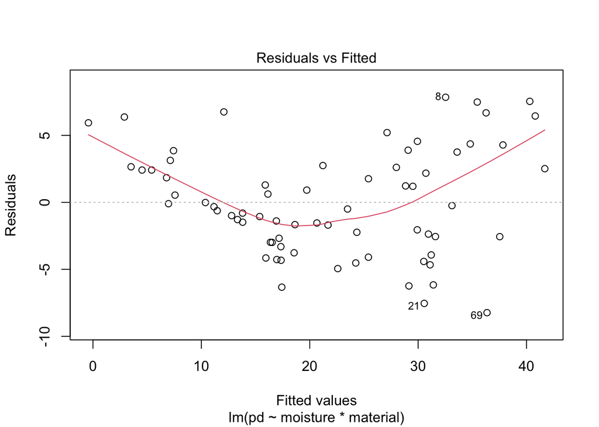

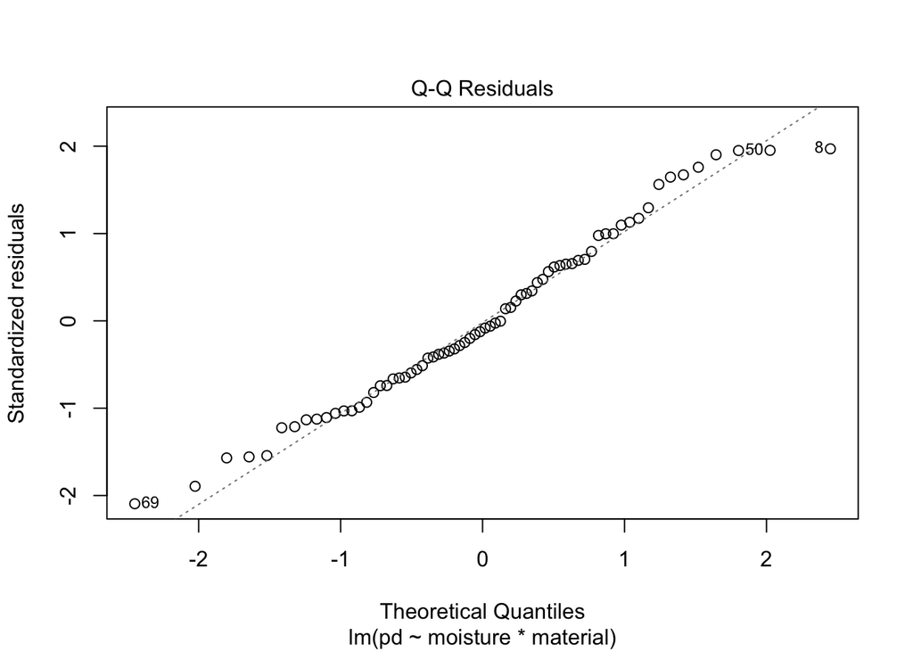

```r
plot(lm.clay, which = 1:2)
```

Diagnostic Plots and Assumptions Linearity: Our assumption is the relationship between the predictors and the response variable is linear. The Residuals vs Fitted plot do not show a random scatter around the horizontal line (zero residuals) especially for the lower values of fited values.

Normality of Errors: Our assumption is that residuals (errors) are normally distributed. The Normal Q-Q plot show the residuals falling along the reference line but have deviations for lower and bigger values.

Homoscedasticity: Variance of the error term seems like it is not constant.

To achieve some improvement I can consider: transforming the response variable or predictors, add additional or more relevant predictors, or introduce non-linear relationship.

## Problem 4) Using Multiple regression to fit nonlinear data (8 points; 2 pt each)

Open the dataset `multData.csv`. This data set consists of three predictor variables, simply named `X1`, `X2` and `X3`. The response variable is `Y`. In this problem you will explore how to use the multiple regression model to model nonlinear relationships.

```r
data <- read.csv("multData.csv")
print("First few rows of the dataset:")
```

```
## [1] "First few rows of the dataset:"
```

```r
head(data)
```

```
##           Y       X1       X2          X3
## 1  82.07603 26.73885 15.06747 -0.05545391
## 2 184.52415 16.41735 15.81520 -0.07657111
## 3 100.22207 23.60727 15.49825 -0.06466944
## 4  89.47872 23.96346 15.53844 -0.10275309
## 5 145.99075 19.14018 15.82856 -0.06808981
## 6  75.14106 24.02841 15.78745 -0.14336107
```

### a) the first model

First we will explore the relationship between $Y$ and the first two predictors $X1$ and $X2$. Fit the linear model

$$Y = \beta_0 + \beta_1 X_1 + \beta_2 X_2
+ \epsilon$$
Interpret the coefficients of both X1 and X2.

```r
# Fit multiple regression model
model <- lm(Y ~ X1 + X2, data = data)

summary(model)
```

```
##
## Call:
## lm(formula = Y ~ X1 + X2, data = data)
##
## Residuals:
##      Min       1Q   Median       3Q      Max
## -19.8649  -7.1965   0.2892   6.7130  20.5860
##
## Coefficients:
##             Estimate Std. Error t value Pr(>|t|)
## (Intercept) 948.5316    75.3339   12.59  < 2e-16 ***
## X1          -12.6318     0.2439  -51.78  < 2e-16 ***
## X2          -35.1420     4.8472   -7.25 3.42e-09 ***
## ---
## Signif. codes:  0 '***' 0.001 '**' 0.01 '*' 0.05 '.' 0.1 ' ' 1
##
## Residual standard error: 10.29 on 47 degrees of freedom
## Multiple R-squared:  0.9831, Adjusted R-squared:  0.9824
## F-statistic:  1371 on 2 and 47 DF,  p-value: < 2.2e-16
```

> In aditive model

> The intercept is 948.53, represents the estimated value of the dependent variable Y, when both predictros X1, X2 are equal to zero.

> estimate for X1 is -12.6318, with Std 0.2439. estimate for X2 is -35.1420, with Std 4.8472.

> Both coefficients are negative, indicating that a one-unit increase in either predictor (X1 or X2) will result in a decrease of 12.63 or 35.14 units in the predicted value of the dependent variable, respectively, while keeping the other predictor constant.

> Both p-values are extremely small (2e-16 and 3.42e-09), indicating that the effects of X1 and X2 on Y are highly statistically significant. The Multiple R-squared value of 0.9831, along with the almost identical Adjusted R-squared value of 0.9824, suggests that the model explains approximately 98% of the variability in the dependent variable.

### b) Investigating interaction of quantitative predictors

Next introduce an interaction term to the model
$$Y = \beta_0 + \beta_1 X_1 + \beta_2 X_2 + \beta_3
X_1\cdot X_2 + \epsilon$$

Fit the model and view the summary output. Has this improved the model fit? Did anything surprising happen to the coefficients? Try to explain what happened.

```r
model_interaction <- lm(Y ~ X1 * X2, data = data)  # `X1 * X2` includes both main effects and interaction

summary(model_interaction)
```

```
##
## Call:
## lm(formula = Y ~ X1 * X2, data = data)
##
## Residuals:
##      Min       1Q   Median       3Q      Max
## -18.9683  -6.4850   0.3495   7.5219  16.6880
##
## Coefficients:
##             Estimate Std. Error t value Pr(>|t|)
## (Intercept) 298.9182   239.2336   1.249  0.21781
## X1           19.0469    11.1545   1.708  0.09446 .
## X2            6.7768    15.4337   0.439  0.66265
## X1:X2        -2.0441     0.7196  -2.841  0.00669 **
## ---
## Signif. codes:  0 '***' 0.001 '**' 0.01 '*' 0.05 '.' 0.1 ' ' 1
##
## Residual standard error: 9.589 on 46 degrees of freedom
## Multiple R-squared:  0.9857, Adjusted R-squared:  0.9847
## F-statistic:  1054 on 3 and 46 DF,  p-value: < 2.2e-16
```

```r
cor(data$X1, data$X2)
```

```
## [1] 0.00988581
```

> In interaction model

> estimate for X1 is 19.0469 with Std 11.1545 estimate for X2 is 6.7768, with Std 15.4337 and X1:X2 estimate -2.0441 with Std 0.7196 Only p value for X1:X2 estimate with value 0.00669 (< 0.05) is significant. This suggest that effect of X1 on X2 depends and vice versa. Looking on correlation coefficient between X1 and X2 it is small 0.00988581

> Multiple R-squared is 0.9857 and almost the same Adjusted R-squared: 0.9847, meaning that model explains around 98% of variability

> Comparing both models through their R-squared and Adjusted R-squared that are around 98% we cant’see difference.

> Comparing both models estimated Residual standard errors are 10.29 on d.f=47 for additive and 9.589 on d.f=46 for interaction model, that seems small preference for interaction model.

### c) Introducing the last predictor

Next fit a model that introduces the `X3` variable.

$$Y = \beta_0 + \beta_1 X_1 + \beta_2 X_2
+ \beta_3 X_1\cdot X_2 + \beta_4 X_3 \epsilon$$
Has the model fit improved? In what way (Justify your answer)?

```r
# Fit the model with interaction and X3
model_full <- lm(Y ~ X1 * X2 + X3, data = data)

# Display summary of the model
summary(model_full)
```

```
##
## Call:
## lm(formula = Y ~ X1 * X2 + X3, data = data)
##
## Residuals:
##      Min       1Q   Median       3Q      Max
## -1.91799 -0.66205 -0.09031  0.67703  2.12326
##
## Coefficients:
##              Estimate Std. Error t value Pr(>|t|)
## (Intercept) 101.56434   25.91680   3.919    3e-04 ***
## X1           26.14504    1.20478  21.701  < 2e-16 ***
## X2           19.91029    1.67276  11.903 1.69e-15 ***
## X3           95.43888    1.52178  62.715  < 2e-16 ***
## X1:X2        -2.51881    0.07775 -32.397  < 2e-16 ***
## ---
## Signif. codes:  0 '***' 0.001 '**' 0.01 '*' 0.05 '.' 0.1 ' ' 1
##
## Residual standard error: 1.031 on 45 degrees of freedom
## Multiple R-squared:  0.9998, Adjusted R-squared:  0.9998
## F-statistic: 6.935e+04 on 4 and 45 DF,  p-value: < 2.2e-16
```

### d) Considering higher order terms

Finally explore higher order terms for the X3 variable: Introduce $X3^2$, $X3^3$ etc and determine if any of these higher order terms are justified in the model. Explain your reasoning and present your final model. Look at the diagnostic plots and discuss whether the assumptions of the multiple regression model seem to be justified.

```r
# Add higher-order terms for X3
data$X3_squared <- data$X3^2
data$X3_cubed <- data$X3^3

# Fit the base model
model_base <- lm(Y ~ X1 * X2 + X3, data = data)

# Add X3^2
model_X3_squared <- lm(Y ~ X1 * X2 + X3 + X3_squared, data = data)

# Add X3^2 and X3^3
model_X3_cubed <- lm(Y ~ X1 * X2 + X3 + X3_squared + X3_cubed, data = data)

# Compare models
summary(model_base)
```

```
##
## Call:
## lm(formula = Y ~ X1 * X2 + X3, data = data)
##
## Residuals:
##      Min       1Q   Median       3Q      Max
## -1.91799 -0.66205 -0.09031  0.67703  2.12326
##
## Coefficients:
##              Estimate Std. Error t value Pr(>|t|)
## (Intercept) 101.56434   25.91680   3.919    3e-04 ***
## X1           26.14504    1.20478  21.701  < 2e-16 ***
## X2           19.91029    1.67276  11.903 1.69e-15 ***
## X3           95.43888    1.52178  62.715  < 2e-16 ***
## X1:X2        -2.51881    0.07775 -32.397  < 2e-16 ***
## ---
## Signif. codes:  0 '***' 0.001 '**' 0.01 '*' 0.05 '.' 0.1 ' ' 1
##
## Residual standard error: 1.031 on 45 degrees of freedom
## Multiple R-squared:  0.9998, Adjusted R-squared:  0.9998
## F-statistic: 6.935e+04 on 4 and 45 DF,  p-value: < 2.2e-16
```

```r
summary(model_X3_squared)
```

```
##
## Call:
## lm(formula = Y ~ X1 * X2 + X3 + X3_squared, data = data)
##
## Residuals:
##      Min       1Q   Median       3Q      Max
## -1.82628 -0.71589 -0.05659  0.48972  2.01384
##
## Coefficients:
##              Estimate Std. Error t value Pr(>|t|)
## (Intercept) 110.50654   25.27986   4.371 7.44e-05 ***
## X1           25.49160    1.19838  21.272  < 2e-16 ***
## X2           19.31355    1.63317  11.826 2.97e-15 ***
## X3           96.80698    1.59664  60.632  < 2e-16 ***
## X3_squared   31.18962   14.51952   2.148   0.0372 *
## X1:X2        -2.47661    0.07734 -32.023  < 2e-16 ***
## ---
## Signif. codes:  0 '***' 0.001 '**' 0.01 '*' 0.05 '.' 0.1 ' ' 1
##
## Residual standard error: 0.9921 on 44 degrees of freedom
## Multiple R-squared:  0.9999, Adjusted R-squared:  0.9998
## F-statistic: 5.993e+04 on 5 and 44 DF,  p-value: < 2.2e-16
```

```r
summary(model_X3_cubed)
```

```
##
## Call:
## lm(formula = Y ~ X1 * X2 + X3 + X3_squared + X3_cubed, data = data)
##
## Residuals:
##     Min      1Q  Median      3Q     Max
## -1.8343 -0.5830 -0.1079  0.5186  2.1132
##
## Coefficients:
##               Estimate Std. Error t value Pr(>|t|)
## (Intercept)  105.68641   24.89511   4.245 0.000114 ***
## X1            25.73271    1.18099  21.789  < 2e-16 ***
## X2            19.62914    1.60859  12.203 1.47e-15 ***
## X3           100.93679    2.86617  35.217  < 2e-16 ***
## X3_squared    13.84539   17.42690   0.794 0.431277
## X3_cubed    -218.67826  127.23802  -1.719 0.092870 .
## X1:X2         -2.49209    0.07621 -32.700  < 2e-16 ***
## ---
## Signif. codes:  0 '***' 0.001 '**' 0.01 '*' 0.05 '.' 0.1 ' ' 1
##
## Residual standard error: 0.9707 on 43 degrees of freedom
## Multiple R-squared:  0.9999, Adjusted R-squared:  0.9998
## F-statistic: 5.216e+04 on 6 and 43 DF,  p-value: < 2.2e-16
```

```r
# Use ANOVA to compare nested models
anova(model_base, model_X3_squared)
```

```
## Analysis of Variance Table
##
## Model 1: Y ~ X1 * X2 + X3
## Model 2: Y ~ X1 * X2 + X3 + X3_squared
##   Res.Df    RSS Df Sum of Sq      F  Pr(>F)
## 1     45 47.845
## 2     44 43.304  1    4.5414 4.6144 0.03725 *
## ---
## Signif. codes:  0 '***' 0.001 '**' 0.01 '*' 0.05 '.' 0.1 ' ' 1
```

```r
anova(model_X3_squared, model_X3_cubed)
```

```
## Analysis of Variance Table
##
## Model 1: Y ~ X1 * X2 + X3 + X3_squared
## Model 2: Y ~ X1 * X2 + X3 + X3_squared + X3_cubed
##   Res.Df    RSS Df Sum of Sq      F  Pr(>F)
## 1     44 43.304
## 2     43 40.521  1    2.7835 2.9538 0.09287 .
## ---
## Signif. codes:  0 '***' 0.001 '**' 0.01 '*' 0.05 '.' 0.1 ' ' 1
```

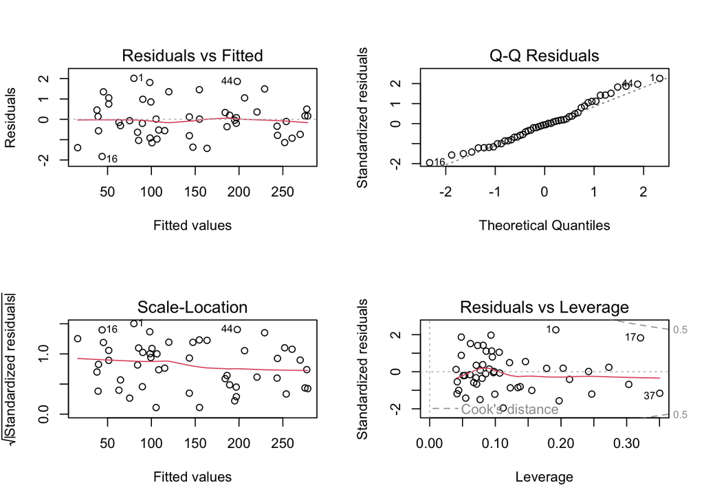

```r
# Plot diagnostic plots for the best model
par(mfrow = c(2, 2))
plot(model_X3_squared)
```

> The initial model, including the main effects and interaction terms, showed excellent fit statistics, with a high adjusted coefficient of determination and a low residual standard error, suggesting it explained nearly all the variability in the outcome variable.

> Adding the square of the predictor improved the model fit marginally. The residual standard error decreased, and the adjusted coefficient of determination remained high. The additional squared term was statistically significant, indicating that it contributed to explaining variability in the outcome. A formal statistical test (Anova) comparing the base and updated models supported this conclusion, with a significant test result justifying the inclusion of the squared term.

> When the cubic term of the predictor was added, the results indicated diminishing returns. While the residual standard error decreased slightly, the cubic term was not statistically significant, and the comparison (Anova) test between the quadratic and cubic models did not support adding this term. This suggests that the cubic term added complexity without a substantial benefit to the model.

> An analysis of diagnostic plots for the model that included the squared term showed no significant violations of regression assumptions. The residuals were randomly distributed without any noticeable patterns, and the normality plot indicated that the residuals followed an approximately normal distribution. These diagnostics confirmed that the model assumptions were met.

> In summary, incorporating the squared term enhanced the model and was statistically justified, whereas the cubic term did not add meaningful value. The final model, including the main effects, interaction terms, and the squared term, strikes an appropriate balance between complexity and explanatory power while effectively capturing the relationship between the predictors and the outcome.